# Cardiometabolic Risk in NHANES 2017–2018

## 8 Collinearity diagnostics

Before running any regression we need to know which candidate predictors are too tightly correlated to coexist in the same specification. Two relationships dominate cardiometabolic data: **BMI vs. waist circumference** (essentially the same construct measured two ways) and **systolic vs. diastolic blood pressure** (correlated through the underlying mean arterial pressure). A model that includes both members of either pair will produce inflated standard errors and unstable coefficients.

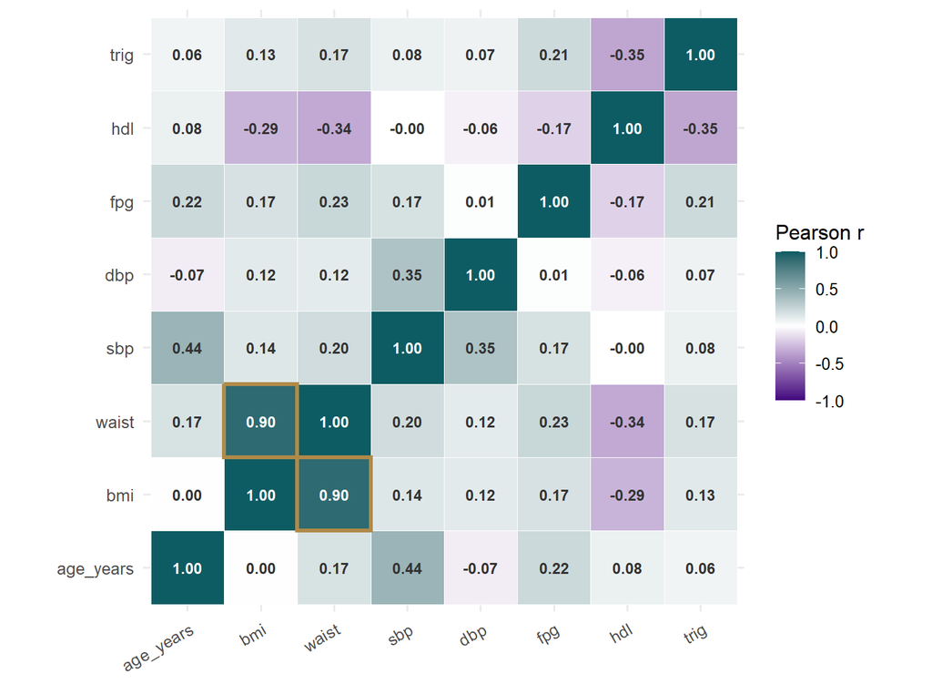

```r
cont_pred <- dat |>
  dplyr::select(age_years, bmi, waist, sbp, dbp, fpg, hdl, trig)

corr <- stats::cor(cont_pred, use = "pairwise.complete.obs", method = "pearson")
corr_long <- as.data.frame(as.table(corr)) |>
  dplyr::rename(x = Var1, y = Var2, r = Freq) |>
  dplyr::mutate(
    flag  = abs(r) >= 0.7 & x != y,
    label = sprintf("%.2f", r)
  )

ggplot(corr_long, aes(x, y, fill = r)) +
  geom_tile(color = "white") +
  geom_text(aes(label = label,
                color = abs(r) > 0.5),
            size = 3.2, fontface = "bold") +
  geom_tile(data = subset(corr_long, flag),
            fill = NA, color = "#b08a49", linewidth = 1.2) +
  scale_fill_gradient2(low = "#3f007d", mid = "white", high = "#0d5c63",
                       midpoint = 0, limits = c(-1, 1),
                       name = "Pearson r") +
  scale_color_manual(values = c(`TRUE` = "white", `FALSE` = "#333"),
                     guide = "none") +
  coord_fixed() +
  labs(x = NULL, y = NULL) +
  theme(axis.text.x = element_text(angle = 30, hjust = 1))
```

```r
# Compute per-dummy VIFs from the design matrix of the exact specification
# we're about to fit. Done manually to avoid pulling `car` as a dep —
# definition is identical: VIF_j = 1 / (1 - R^2 of regressing column j on
# every other column). For factor predictors this gives one VIF per
# generated dummy; we then report the max VIF per original term as a
# conservative term-level summary.
mm <- stats::model.matrix(~ age_years + sex + race_eth, data = dat)[, -1, drop = FALSE]

vif_dummies <- vapply(seq_len(ncol(mm)), function(j) {
  y      <- mm[, j]
  x      <- cbind(1, mm[, -j, drop = FALSE])
  fit    <- stats::lm.fit(x = x, y = y)
  ss_res <- sum(fit$residuals^2)
  ss_tot <- sum((y - mean(y))^2)
  r2     <- 1 - ss_res / max(ss_tot, .Machine$double.eps)
  1 / max(1 - r2, .Machine$double.eps)
}, numeric(1))
names(vif_dummies) <- colnames(mm)

# Map each generated dummy back to its source term.
term_of <- function(col) {
  if (col == "age_years") return("age_years")
  if (startsWith(col, "sex"))      return("sex")
  if (startsWith(col, "race_eth")) return("race_eth")
  col
}
vif_term <- tapply(vif_dummies, vapply(names(vif_dummies), term_of, character(1)), max)

knitr::kable(
  data.frame(
    Predictor   = names(vif_term),
    `Max VIF`   = round(as.numeric(vif_term), 2),
    Threshold   = "< 5 clean, > 10 problematic",
    check.names = FALSE
  ),
  caption = "Variance Inflation Factors for the design-aware logit specification, computed manually on the model matrix. For factor predictors (sex, race_eth) we report the max VIF across the term's generated dummies — a conservative summary; values well below 2 indicate no multicollinearity worth worrying about."
)
```

| Predictor | Max VIF | Threshold |
| --- | --- | --- |
| age_years | 1.02 | < 5 clean, > 10 problematic |
| race_eth | 2.14 | < 5 clean, > 10 problematic |
| sex | 1.00 | < 5 clean, > 10 problematic |

## 9 Design-aware logistic regression (R)

Using `svyglm` so standard errors reflect NHANES’s clustered, stratified design. Coefficients are log-odds ratios for metabolic syndrome.

**NoteWhy logistic regression?**

The outcome (metabolic syndrome) is **binary** — either the person meets ≥3 of 5 criteria or they don’t. Linear regression on a binary outcome will happily predict negative or > 1 probabilities and gives biased SEs.

**Logistic regression** models the *log-odds* of the outcome as a linear combination of the predictors. The coefficients (after exponentiating) are **odds ratios** — “for each one-year increase in age, the odds of MetS multiply by *X*.” Odds ratios are not risk ratios, but for outcomes that are not very common (< ~10%) they’re a close approximation; for ~33% prevalence, you need to interpret them as odds ratios specifically.

`svyglm()` is the survey-aware version: same likelihood, same odds-ratio interpretation, but the standard errors and p-values use Taylor linearization so they correctly account for the strata + PSU + weights. For a complex-survey dataset, you’d never use plain `glm()` for the headline result — the SEs would be wrong.

```r
dat_fit <- dat |>
  mutate(
    metsyn   = as.integer(metsyn),
    sex      = droplevels(factor(sex)),
    race_eth = droplevels(factor(race_eth))
  )

des_std <- survey::svydesign(
  ids     = ~SDMVPSU,
  strata  = ~SDMVSTRA,
  weights = ~WTMEC4YR,
  data    = dat_fit,
  nest    = TRUE
)

fit <- survey::svyglm(
  metsyn ~ age_years + sex + race_eth,
  design = des_std,
  family = quasibinomial()
)

fit |>
  gtsummary::tbl_regression(exponentiate = TRUE) |>
  gtsummary::modify_caption("**Design-aware odds ratios for metabolic syndrome (complete-case)**")
```

**Design-aware odds ratios for metabolic syndrome (complete-case)**

| **Characteristic** | **OR** | **95% CI** | **p-value** |
| --- | --- | --- | --- |
| age_years | 1.03 | 1.03, 1.04 | <0.001 |
| sex |  |  |  |
| Male | — | — |  |
| Female | 0.97 | 0.79, 1.20 | 0.8 |
| race_eth |  |  |  |
| Mexican American | — | — |  |
| Other Hispanic | 0.70 | 0.55, 0.89 | 0.005 |
| Non-Hispanic White | 0.59 | 0.49, 0.72 | <0.001 |
| Non-Hispanic Black | 0.51 | 0.44, 0.60 | <0.001 |
| Non-Hispanic Asian | 0.43 | 0.35, 0.53 | <0.001 |
| Other Race - Including Multi-Racial | 0.87 | 0.57, 1.32 | 0.5 |

Abbreviations: CI = Confidence Interval, OR = Odds Ratio

## 10 Multiple imputation — beyond complete case

> **In one sentence.** Re-estimate the prevalence and the design-aware logit on the broader cohort with imputation uncertainty propagated through Rubin’s rules — the figure to put in a paper, with complete-case as the sensitivity contrast.

**NoteWhy multiple imputation (and not complete-case or single imputation)?**

Three ways to handle missing data, in increasing order of how much they respect the truth:

1. **Complete-case (CC).** Drop any row with a missing value. Easy, but **biased whenever the missingness depends on something** (here, lipids/glucose are missing because the participant wasn’t in the morning fasting subsample — which skews younger and healthier). The CC prevalence under-estimates the true population prevalence.
2. **Single imputation** (e.g., fill with the mean). Recovers the rows but **understates the standard error** because the imputed values are treated as if they were observed without uncertainty. p-values come out too small; CIs too narrow.
3. **Multiple imputation (MI).** Generate *m* plausible filled-in datasets (we use m=5), run the analysis on each, then **pool** the results with Rubin’s rules — the pooled point estimate is the average across imputations, and the pooled variance has two parts: within-imputation variance (the usual SE) plus between-imputation variance (the part that captures imputation uncertainty). This is the only one of the three that gives **honest** standard errors when data are missing-at-random.

Use MI whenever you have non-trivial missingness on key variables (>5%) and the missingness mechanism could plausibly depend on observed covariates. The `mice` package implements **predictive mean matching** by default — for each missing value, it looks at the few observed cases with the most similar predicted value and donates one of their observed values as the imputation. That keeps imputed values inside the realistic range of the variable.

The complete-case cohort silently drops everyone outside the morning fasting subsample (lipids and glucose are the binding constraint). Multiple Imputation by Chained Equations (MICE) re-fits the prevalence and regression on the broader cohort with imputation uncertainty propagated through Rubin’s rules. We impute the eight clinical measurements (BMI, waist, lipids, BP readings, fasting glucose) with predictive mean matching, holding the design columns (cycle, weight, strata, PSU) and demographics fixed.

```r
mi_input <- dat_full |>
  dplyr::select(
    age_years, sex, race_eth, cycle,
    bmi, waist, trig, hdl, tc, sbp, dbp, fpg,
    dm_dx, bp_treated, smoker,
    SDMVPSU, SDMVSTRA, WTMEC4YR
  ) |>
  dplyr::mutate(
    sex      = droplevels(factor(sex)),
    race_eth = droplevels(factor(race_eth)),
    cycle    = factor(cycle)
  )

# Don't impute design columns or already-complete demographics; they
# stay available as auxiliary predictors (sampling-related missingness
# patterns get propagated through the imputation that way).
meth  <- mice::make.method(mi_input)
preds <- mice::make.predictorMatrix(mi_input)
meth[c("SDMVPSU", "SDMVSTRA", "WTMEC4YR", "cycle",
       "age_years", "sex", "race_eth",
       "dm_dx", "bp_treated", "smoker")] <- ""

set.seed(2026)
mi_obj <- mice::mice(mi_input, m = 5, maxit = 8,
                     method = meth, predictorMatrix = preds,
                     printFlag = FALSE)

cat(sprintf("MICE complete: m = %d imputations × maxit = %d iterations\n",
            mi_obj$m, mi_obj$iteration))
```

```
MICE complete: m = 5 imputations × maxit = 8 iterations
```

```r
# For each imputed dataset, derive metsyn, build the survey design, and
# extract weighted prevalence + variance. Pool with Rubin's rules.
build_metsyn <- function(d) {
  d |>
    dplyr::mutate(
      waist_hit = (sex == "Male"   & waist >= 102) |
                  (sex == "Female" & waist >= 88),
      trig_hit  = trig >= 150,
      hdl_hit   = (sex == "Male"   & hdl < 40) |
                  (sex == "Female" & hdl < 50),
      bp_hit    = sbp >= 130 | dbp >= 85 | bp_treated,
      glu_hit   = fpg >= 100 | dm_dx,
      metsyn    = as.integer(rowSums(cbind(waist_hit, trig_hit, hdl_hit,
                                           bp_hit, glu_hit), na.rm = TRUE) >= 3)
    )
}

imp_results <- lapply(seq_len(mi_obj$m), function(i) {
  d <- build_metsyn(mice::complete(mi_obj, action = i))
  des_i <- survey::svydesign(ids = ~SDMVPSU, strata = ~SDMVSTRA,
                              weights = ~WTMEC4YR, data = d, nest = TRUE)
  prev <- survey::svymean(~metsyn, des_i)
  list(est = as.numeric(coef(prev)), var = as.numeric(stats::vcov(prev)))
})

m    <- length(imp_results)
qs   <- vapply(imp_results, \(x) x$est, numeric(1))
us   <- vapply(imp_results, \(x) x$var, numeric(1))
qbar <- mean(qs)
ubar <- mean(us)
b    <- sum((qs - qbar)^2) / (m - 1)
total_var <- ubar + (1 + 1/m) * b
se        <- sqrt(total_var)

# Compare against complete-case weighted prevalence for the contrast.
cc_prev <- survey::svymean(~as.integer(metsyn), des_std)
cc_est  <- as.numeric(coef(cc_prev))
cc_se   <- sqrt(as.numeric(stats::vcov(cc_prev)))

pretty_kable(
  data.frame(
    Estimator      = c("Complete-case", "MI-pooled (m=5)"),
    Prevalence     = sprintf("%.1f%%", 100 * c(cc_est, qbar)),
    `95% CI`       = c(
      sprintf("%.1f%% – %.1f%%",
              100 * (cc_est - 1.96 * cc_se),
              100 * (cc_est + 1.96 * cc_se)),
      sprintf("%.1f%% – %.1f%%",
              100 * (qbar  - 1.96 * se),
              100 * (qbar  + 1.96 * se))
    ),
    `Cohort n`     = c(format(nrow(dat),      big.mark = ","),
                       format(nrow(dat_full), big.mark = ",")),
    check.names = FALSE
  ),
  caption = "Weighted MetS prevalence: complete-case vs. MI-pooled. The two estimates should differ in the direction predicted by the missing-data mechanism — fasting-subsample exclusion biases CC toward a younger, healthier cohort."
)
```

Weighted MetS prevalence: complete-case vs. MI-pooled. The two estimates should differ in the direction predicted by the missing-data mechanism — fasting-subsample exclusion biases CC toward a younger, healthier cohort.

| Estimator | Prevalence | 95% CI | Cohort n |
| --- | --- | --- | --- |
| Complete-case | 35.3% | 33.1% – 37.6% | 4,314 |
| MI-pooled (m=5) | 40.5% | 38.2% – 42.8% | 10,739 |

```r
fits <- lapply(seq_len(mi_obj$m), function(i) {
  d <- build_metsyn(mice::complete(mi_obj, action = i)) |>
    dplyr::mutate(
      sex      = droplevels(factor(sex)),
      race_eth = droplevels(factor(race_eth))
    )
  des_i <- survey::svydesign(ids = ~SDMVPSU, strata = ~SDMVSTRA,
                              weights = ~WTMEC4YR, data = d, nest = TRUE)
  survey::svyglm(metsyn ~ age_years + sex + race_eth,
                 design = des_i, family = quasibinomial())
})

pooled <- mitools::MIcombine(
  results   = lapply(fits, coef),
  variances = lapply(fits, vcov)
)

ps <- summary(pooled)
```

```
Multiple imputation results:
      MIcombine.default(results = lapply(fits, coef), variances = lapply(fits,
    vcov))
                                                results          se      (lower
(Intercept)                                 -1.62220654 0.103143115 -1.82997100
age_years                                    0.03622268 0.001975451  0.03223064
sexFemale                                   -0.08490220 0.067476706 -0.21849077
race_ethOther Hispanic                      -0.36947184 0.100300047 -0.57503126
race_ethNon-Hispanic White                  -0.54825084 0.093235611 -0.73260990
race_ethNon-Hispanic Black                  -0.57664861 0.077747763 -0.72920490
race_ethNon-Hispanic Asian                  -0.86750221 0.106461465 -1.08586129
race_ethOther Race - Including Multi-Racial -0.25416518 0.185469315 -0.62892548
                                                 upper) missInfo
(Intercept)                                 -1.41444208     33 %
age_years                                    0.04021473     35 %
sexFemale                                    0.04868636     20 %
race_ethOther Hispanic                      -0.16391243     42 %
race_ethNon-Hispanic White                  -0.36389177     18 %
race_ethNon-Hispanic Black                  -0.42409231      6 %
race_ethNon-Hispanic Asian                  -0.64914314     42 %
race_ethOther Race - Including Multi-Racial  0.12059512     35 %
```

```r
# mitools names the lower/upper columns as "(lower" and "upper)" — handle
# both that and tidier alternatives without depending on column order.
lower_col <- grep("lower", colnames(ps), value = TRUE)[1]
upper_col <- grep("upper", colnames(ps), value = TRUE)[1]
miss_col  <- grep("miss",  colnames(ps), value = TRUE, ignore.case = TRUE)[1]

# missInfo can come back numeric (proportion) or string ("25%") depending
# on mitools version; normalize both forms.
mi_info_raw <- ps[[miss_col]]
mi_info_num <- if (is.numeric(mi_info_raw)) {
  mi_info_raw * 100
} else {
  suppressWarnings(as.numeric(sub("%\\s*$", "", as.character(mi_info_raw))))
}

mi_table <- data.frame(
  Term            = rownames(ps),
  OR              = sprintf("%.2f", exp(ps$results)),
  `95% CI (OR)`   = sprintf("%.2f – %.2f",
                            exp(ps[[lower_col]]),
                            exp(ps[[upper_col]])),
  `Frac. missing info` = sprintf("%.1f%%", mi_info_num),
  check.names = FALSE
)

pretty_kable(
  mi_table,
  caption = "Design-aware odds ratios for metabolic syndrome, pooled across 5 multiple imputations using Rubin's rules. The 'Frac. missing info' column estimates the share of variance in each coefficient attributable to imputation noise — values above 30% are the threshold for raising m above 5 in a published analysis."
)
```

Design-aware odds ratios for metabolic syndrome, pooled across 5 multiple imputations using Rubin's rules. The 'Frac. missing info' column estimates the share of variance in each coefficient attributable to imputation noise — values above 30% are the threshold for raising m above 5 in a published analysis.

| Term | OR | 95% CI (OR) | Frac. missing info |
| --- | --- | --- | --- |
| (Intercept) | 0.20 | 0.16 – 0.24 | 33.0% |
| age_years | 1.04 | 1.03 – 1.04 | 35.0% |
| sexFemale | 0.92 | 0.80 – 1.05 | 20.0% |
| race_ethOther Hispanic | 0.69 | 0.56 – 0.85 | 42.0% |
| race_ethNon-Hispanic White | 0.58 | 0.48 – 0.69 | 18.0% |
| race_ethNon-Hispanic Black | 0.56 | 0.48 – 0.65 | 6.0% |
| race_ethNon-Hispanic Asian | 0.42 | 0.34 – 0.52 | 42.0% |
| race_ethOther Race - Including Multi-Racial | 0.78 | 0.53 – 1.13 | 35.0% |

## 11 Gradient boosting + SHAP (Python)

**NoteWhy AUC, Brier, and a calibration plot — together?**

A clinical-prediction model has two jobs: **rank** patients by risk (discrimination) and **assign realistic probability numbers** (calibration). Different metrics measure different things.

- **AUC (Area Under the ROC Curve)** is a pure ranking metric. It answers: *if I draw one random MetS+ and one random MetS- person, what’s the probability the model assigns higher risk to the MetS+ one?* AUC = 0.5 is coin-flip; 1.0 is perfect ranking. AUC says nothing about whether the predicted probabilities are realistic.
- **Brier score** is the mean squared error between predicted probability and actual outcome (0 or 1). Lower = better. Unlike AUC, Brier penalizes both bad ranking *and* miscalibration in one number.
- **Calibration plot (reliability curve)** shows, for each decile of predicted probability, what fraction of patients actually had the outcome. A perfectly calibrated model lies on the y = x diagonal. Above the diagonal: under-predicting; below: over-predicting.

For a screening tool that hands a patient a “your estimated risk is X%,” **calibration matters more than AUC**. A miscalibrated model with high AUC is dangerous because it sorts patients correctly but mislabels their absolute risk. For deciding *who* to screen, AUC is enough. For telling them *what* their risk is, you need calibration.

We hand the same cohort to Python via `reticulate`. Critically, we **do not** use the five ATP III components (waist, triglycerides, HDL, blood pressure, fasting glucose) as predictors — those define the outcome, so including them yields a tautological AUC ≈ 1.0. A physician-scientist’s first job with any black-box model is to catch that kind of leakage before the output looks impressive.

Instead we ask a more interesting question: *how far can basic demographics and adiposity alone carry us toward identifying people at elevated metabolic-syndrome risk?* The answer is a useful screening tool — not a replacement for labs.

```python
df = r.dat.copy()
df["metsyn"] = df["metsyn"].astype(int)

features = ["age_years", "sex", "race_eth", "bmi"]
df = df[features + ["metsyn"]].dropna()
df = pd.get_dummies(df, columns=["sex", "race_eth"], drop_first=True)

X = df.drop(columns="metsyn")
y = df["metsyn"]

X_tr, X_te, y_tr, y_te = train_test_split(
    X, y, test_size=0.25, stratify=y, random_state=42
)

model = xgb.XGBClassifier(
    n_estimators=400, max_depth=4, learning_rate=0.05,
    subsample=0.9, colsample_bytree=0.9,
    eval_metric="logloss", random_state=42,
)
model.fit(X_tr, y_tr)
```

```
XGBClassifier(base_score=None, booster=None, callbacks=None,
              colsample_bylevel=None, colsample_bynode=None,
              colsample_bytree=0.9, device=None, early_stopping_rounds=None,
              enable_categorical=False, eval_metric='logloss',
              feature_types=None, feature_weights=None, gamma=None,
              grow_policy=None, importance_type=None,
              interaction_constraints=None, learning_rate=0.05, max_bin=None,
              max_cat_threshold=None, max_cat_to_onehot=None,
              max_delta_step=None, max_depth=4, max_leaves=None,
              min_child_weight=None, missing=nan, monotone_constraints=None,
              multi_strategy=None, n_estimators=400, n_jobs=None,
              num_parallel_tree=None, ...)
```

```python
p_te = model.predict_proba(X_te)[:, 1]
print(f"AUC:   {roc_auc_score(y_te, p_te):.3f}")
```

```
AUC:   0.764
```

```python
print(f"Brier: {brier_score_loss(y_te, p_te):.3f}")
```

```
Brier: 0.193
```

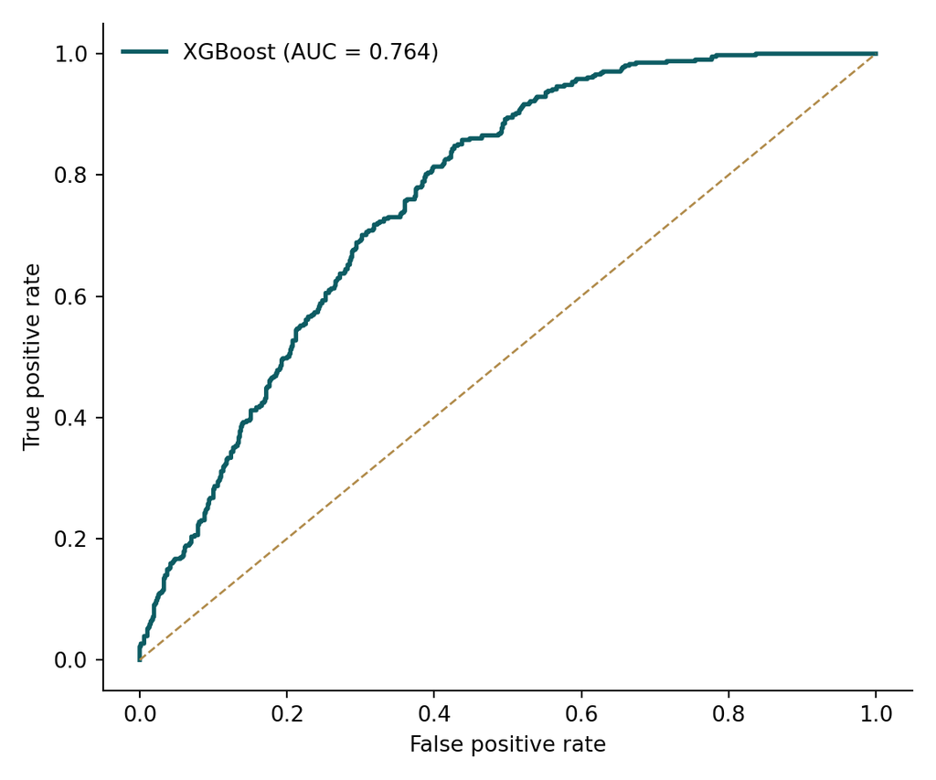

Figure 1: ROC curve, held-out 25% test set. Demographics + BMI alone achieve useful discrimination — well below the perfect AUC that including ATP III components would falsely produce.

```python
fpr, tpr, _ = roc_curve(y_te, p_te)
fig, ax = plt.subplots(figsize=(6, 5))
_ = ax.plot(fpr, tpr, color="#0d5c63", lw=2,
            label=f"XGBoost (AUC = {roc_auc_score(y_te, p_te):.3f})")
_ = ax.plot([0, 1], [0, 1], ls="--", color="#b08a49", lw=1)
_ = ax.set(xlabel="False positive rate", ylabel="True positive rate")
_ = ax.legend(frameon=False)
_ = ax.spines[["top", "right"]].set_visible(False)
plt.tight_layout()
plt.show()
```

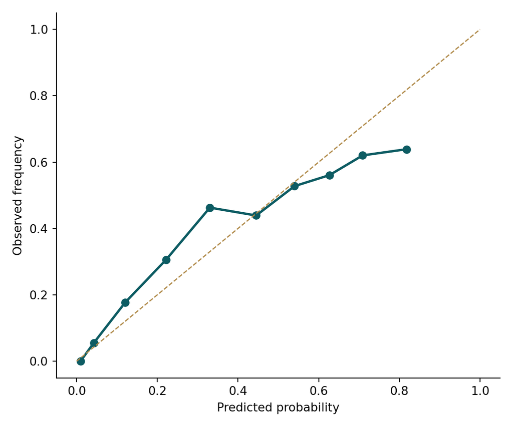

Figure 2: Calibration. Perfectly calibrated models lie on the diagonal; dots above the line mean the model under-estimates true risk in that decile.

```python
prob_true, prob_pred = calibration_curve(y_te, p_te, n_bins=10, strategy="quantile")
fig, ax = plt.subplots(figsize=(6, 5))
_ = ax.plot(prob_pred, prob_true, "o-", color="#0d5c63", lw=2)
_ = ax.plot([0, 1], [0, 1], ls="--", color="#b08a49", lw=1)
_ = ax.set(xlabel="Predicted probability", ylabel="Observed frequency")
_ = ax.spines[["top", "right"]].set_visible(False)
plt.tight_layout()
plt.show()
```

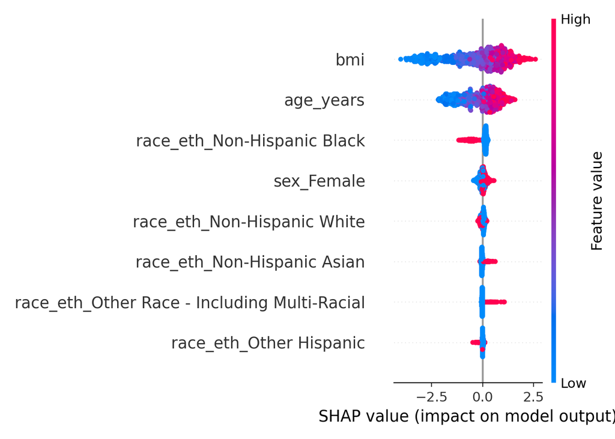

Figure 3: SHAP summary. Each dot is one held-out adult; color is feature value, x-position is SHAP contribution to the log-odds of metabolic syndrome.

```python
explainer = shap.TreeExplainer(model)
shap_values = explainer(X_te)
shap.summary_plot(shap_values, X_te, show=False, plot_size=(7, 5))
plt.tight_layout()
plt.show()
```

## 12 Pooled Cohort Equations — head-to-head comparator

> **In one sentence.** Compare against an established clinical risk score on two axes — distribution (does PCE risk track MetS status?) and same-outcome AUC (does a logit on PCE inputs beat demographics + BMI?) — so the model has a benchmark, not just a number.

The 2013 ACC/AHA Pooled Cohort Equations (PCE; Goff et al. 2014) is the established 10-year ASCVD risk score in US guidelines. Its outcome (incident ASCVD over 10 years) doesn’t match ours (cross-sectional metabolic syndrome), so a direct AUC comparison would be apples-to-oranges. We do two complementary checks instead:

1. **Construct-validity check.** PCE-predicted ASCVD risk should run higher among MetS-positive adults than MetS-negative on the same cohort — if the two scores are measuring overlapping cardiovascular biology, they should track.
2. **Same-outcome head-to-head.** Refit a logit on PCE *inputs* (age, sex, race, total cholesterol, HDL, SBP, BP-treated, current smoker, diabetes) to predict our MetS outcome. Compare AUC against the demographics+BMI XGBoost. Same outcome, two different feature sets — that’s the publishable head-to-head.

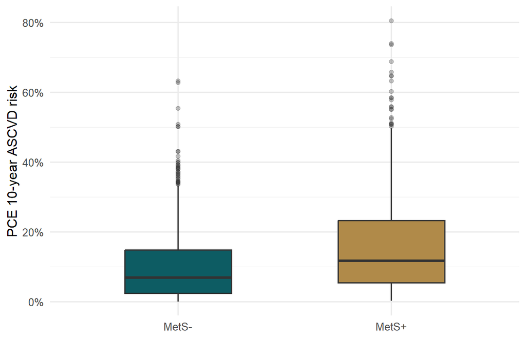

Construct validity check. PCE 10-year ASCVD risk distribution by metabolic-syndrome status, complete-case adults aged 40–79 (PCE’s supported age range). Higher PCE risk in the MetS+ group is the expected direction; the Wilcoxon test below quantifies the gap.

```r
dat_pce <- dat |>
  dplyr::mutate(
    race_pce = dplyr::case_when(
      stringr::str_detect(as.character(race_eth), "Non-Hispanic White") ~ "White",
      stringr::str_detect(as.character(race_eth), "Non-Hispanic Black") ~ "Black",
      TRUE ~ NA_character_
    ),
    pce_risk = pce_risk(
      age = age_years, sex = as.character(sex), race = race_pce,
      tc = tc, hdl = hdl, sbp = sbp,
      treated = bp_treated, smoker = smoker, diabetes = dm_dx
    )
  ) |>
  dplyr::filter(!is.na(pce_risk))

ggplot(dat_pce, aes(x = factor(metsyn,
                                levels = c(FALSE, TRUE),
                                labels = c("MetS-", "MetS+")),
                    y = pce_risk,
                    fill = metsyn)) +
  geom_boxplot(width = 0.5, outlier.alpha = 0.3) +
  scale_fill_manual(values = c("FALSE" = "#0d5c63", "TRUE" = "#b08a49"),
                    guide = "none") +
  scale_y_continuous(labels = scales::percent_format(accuracy = 1)) +
  labs(x = NULL, y = "PCE 10-year ASCVD risk")
```

```r
w <- stats::wilcox.test(pce_risk ~ metsyn, data = dat_pce)
cat(sprintf(
  "Median PCE 10-yr ASCVD risk:\n  MetS- : %.1f%%\n  MetS+ : %.1f%%\nWilcoxon p (one-sided MetS+ > MetS-) : %s\nN with PCE-eligible inputs (age 40-79, NH White/Black) : %s\n",
  100 * stats::median(dat_pce$pce_risk[!dat_pce$metsyn]),
  100 * stats::median(dat_pce$pce_risk[ dat_pce$metsyn]),
  format.pval(w$p.value, eps = 1e-300),
  format(nrow(dat_pce), big.mark = ",")
))
```

```
Median PCE 10-yr ASCVD risk:
  MetS- : 6.9%
  MetS+ : 11.8%
Wilcoxon p (one-sided MetS+ > MetS-) : 9.4491e-22
N with PCE-eligible inputs (age 40-79, NH White/Black) : 1,512
```

```python
from sklearn.linear_model import LogisticRegression

dpce = r.dat_pce.copy()
dpce["metsyn"] = dpce["metsyn"].astype(int)

pce_features = ["age_years", "sex", "race_pce", "tc", "hdl", "sbp",
                "bp_treated", "smoker", "dm_dx"]

dpce_model = pce_features + ["metsyn"]
dpce = dpce[dpce_model].dropna()
dpce = pd.get_dummies(dpce, columns=["sex", "race_pce"], drop_first=True)
for c in ["bp_treated", "smoker", "dm_dx"]:
    dpce[c] = dpce[c].astype(int)

Xp = dpce.drop(columns="metsyn")
yp = dpce["metsyn"]
Xp_tr, Xp_te, yp_tr, yp_te = train_test_split(
    Xp, yp, test_size=0.25, stratify=yp, random_state=42
)
pce_logit = LogisticRegression(max_iter=2000).fit(Xp_tr, yp_tr)
p_pce = pce_logit.predict_proba(Xp_te)[:, 1]

auc_pce = roc_auc_score(yp_te, p_pce)
auc_xgb = roc_auc_score(y_te, p_te)
brier_pce = brier_score_loss(yp_te, p_pce)
brier_xgb = brier_score_loss(y_te, p_te)

print(f"AUC, PCE-input logit                   : {auc_pce:.3f}")
```

```
AUC, PCE-input logit                   : 0.848
```

```python
print(f"AUC, demographics+BMI XGBoost          : {auc_xgb:.3f}")
```

```
AUC, demographics+BMI XGBoost          : 0.764
```

```python
print(f"Brier, PCE-input logit                 : {brier_pce:.3f}")
```

```
Brier, PCE-input logit                 : 0.160
```

```python
print(f"Brier, demographics+BMI XGBoost        : {brier_xgb:.3f}")
```

```
Brier, demographics+BMI XGBoost        : 0.193
```

```python
print(f"\nN (PCE-input cohort)  : {len(dpce):,}")
```

```
N (PCE-input cohort)  : 1,512
```

```python
print(f"N (XGBoost cohort)    : {len(y_te) + len(y_tr):,}")
```

```
N (XGBoost cohort)    : 4,305
```

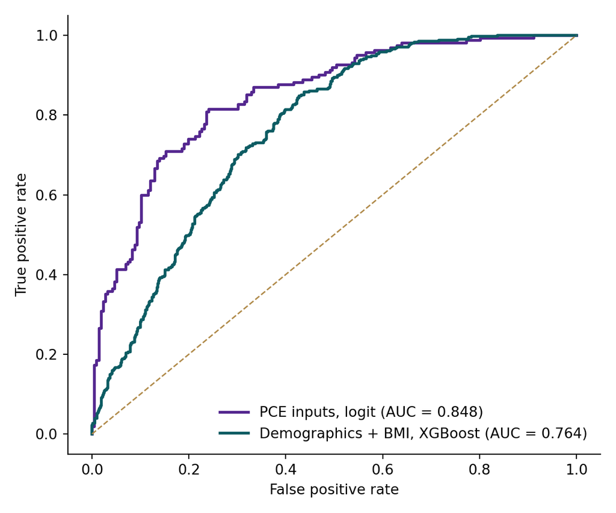

```python
fpr_pce, tpr_pce, _ = roc_curve(yp_te, p_pce)
fpr_xgb, tpr_xgb, _ = roc_curve(y_te, p_te)

fig, ax = plt.subplots(figsize=(6, 5))
_ = ax.plot(fpr_pce, tpr_pce, color="#54278f", lw=2,
            label=f"PCE inputs, logit (AUC = {auc_pce:.3f})")
_ = ax.plot(fpr_xgb, tpr_xgb, color="#0d5c63", lw=2,
            label=f"Demographics + BMI, XGBoost (AUC = {auc_xgb:.3f})")
_ = ax.plot([0, 1], [0, 1], ls="--", color="#b08a49", lw=1)
_ = ax.set(xlabel="False positive rate", ylabel="True positive rate")
_ = ax.legend(frameon=False, loc="lower right")
_ = ax.spines[["top", "right"]].set_visible(False)
plt.tight_layout()
plt.show()
```

## 14 Caveats and what would change the picture

- **Cross-sectional, not incident.** MetS here is a contemporaneous diagnosis from concurrent labs, not 10-year incident ASCVD. The PCE comparator works as a *score-distribution* and *same-outcome* analysis but a true head-to-head needs the NHANES Linked Mortality Files (NHANES-LMF) and a survival model — Cox or competing-risks — on the actual 10-year ASCVD event.
- **No SDoH layer.** Without census-tract income, food access, or PLACES indicators, the model can only see individual-level demographics — almost certainly leaving structural risk on the table, especially for groups underrepresented in the PCE training cohorts (Asian, Hispanic, multi-racial).
- **PCE itself has known equity limitations.** The Goff 2014 specification only supports non-Hispanic White and non-Hispanic Black race assignments; everyone else gets NA. That is a limitation of the score, not of this implementation, but it’s the kind of caveat a reviewer will flag — and the right answer is to also report PREVENT (the 2023 AHA replacement that drops the race term) on the same cohort.
- **MICE single-source.** We impute with default predictive mean matching and don’t run sensitivity analyses at m = 20 or with alternative imputation methods (random forest, joint modeling). For a methods note, that’s the next sensitivity check.

## 15 Next steps

- **Decision-curve analysis** at clinically-relevant probability thresholds (5%, 10%, 20%) for each model, with net-benefit reported alongside AUC. That’s the analysis a clinical-utility paper actually needs.
- **PREVENT score comparator** alongside PCE — the 2023 AHA model is the published replacement and the natural sensitivity check on PCE’s race term.
- **NHANES-LMF survival analysis** for the real PCE head-to-head on incident ASCVD over 10-year follow-up.
- **SDoH enrichment** from ACS / CDC PLACES at census-tract level and a re-fit to test whether mis-ranking of socioeconomically vulnerable groups shrinks materially with structural covariates.
- **Subgroup SHAP** within race/ethnicity strata to test for differential prediction — the algorithmic-fairness check that any clinical-prediction reviewer will request.
- **Splines on age and age × sex interaction** in the design-aware logit — the two most common reviewer comments on cardiometabolic models.

## 16 Appendix — TRIPOD+AI reporting checklist

For ML-based clinical prediction models, major journals (BMJ, JAMA, Annals) now require **TRIPOD+AI** (Transparent Reporting of a multivariable prediction model for Individual Prognosis Or Diagnosis, AI extension; Collins et al. 2024, BMJ). Each item below is a pointer to where in this notebook the requirement is met or, where not met, the explicit gap.

| # | TRIPOD+AI item | Where addressed | Status |
| --- | --- | --- | --- |
| 1 | Title identifies model purpose, target population, outcome | Document title and subtitle | ✓ |
| 2 | Structured summary of design, predictors, outcomes, performance | “Why this analysis” + Conclusions | ✓ |
| 3 | Background / scientific rationale | “Why this analysis” | ✓ |
| 4 | Specific objectives, including model purpose (diagnosis vs. prognosis) | “Why this analysis” — diagnostic, cross-sectional | ✓ |
| 5 | Source of data, dates, setting | NHANES 2015–2018 (cycles I + J), described in `pull-data` | ✓ |
| 6 | Eligibility criteria, treatments | Adult ≥ 20 years, complete-case for primary; MI for sensitivity | ✓ |
| 7 | Outcome definition, with sensitivity to alternative definitions | `define-outcome` chunk + `mets-sensitivity` (NCEP/IDF/JIS) | ✓ |
| 8 | Predictors with justification | `define-outcome` + `collinearity-corr` + `collinearity-vif` | ✓ |
| 9 | Sample size justification | Cohort sketch in EDA section; pooling rationale in `pull-data` | Partial — no formal power calc |
| 10 | Missing data handling | `eda-missingness`, `eda-selection-bias`, `mi-impute`, `mi-prevalence` | ✓ |
| 11 | Statistical methods (model type, regularization, hyperparameters) | `svyglm`, `mi-svyglm`, `handoff` (XGBoost: 400 trees, depth 4, lr 0.05) | ✓ |
| 12 | Validation / resampling strategy | 75/25 stratified split with `random_state=42` | Partial — no external validation |
| 13 | Performance measures (discrimination + calibration) | `fig-roc`, `fig-calibration`, AUC + Brier reported | ✓ |
| 14 | Subgroup performance | Subgroup SHAP listed in Next Steps | **Gap** |
| 15 | Handling of class imbalance / fairness considerations | PCE race-term limitation called out in Caveats | Partial |
| 16 | Interpretability methods | `fig-shap` global SHAP | ✓ — global only |
| 17 | Comparison with existing prediction models | `pce-construct-validity`, `fig-pce-vs-xgb-auc` | ✓ |
| 18 | Algorithmic fairness assessment | Caveats note PCE race limitation; subgroup SHAP in Next Steps | **Gap** |
| 19 | Multiplicity / multiple-comparisons correction | Single-outcome model; no FDR needed for the primary AUC | N/A |
| 20 | Deployment and clinical-implementation considerations | Calibration emphasized over AUC for clinical use | ✓ |
| 21 | Limitations | Caveats section — cross-sectional, MI single-source, PCE race | ✓ |
| 22 | Funding | Not applicable (portfolio analysis) | N/A |
| 23 | Code availability | renv.lock + qmd source on GitHub | ✓ |
| 24 | Data availability | NHANES is public; specific files listed in `pull-data` | ✓ |
| 25 | Conflicts of interest | None declared | ✓ |

The two open gaps (subgroup performance / algorithmic-fairness assessment) are exactly the items called out in the Next Steps section. A publishable version would close both before submission.

## 17 Methods primer

Every statistical test or estimator used above, with a one-line definition, what it tests, when you’d use it, the key assumption, and what to do if that assumption fails.

| Method | What it does | Why used here | Key assumption | If assumption fails |
| --- | --- | --- | --- | --- |
| **Skewness, excess kurtosis** (`e1071::skewness/kurtosis`) | Two numbers describing the shape of a distribution. Skew measures asymmetry (right-skew = long upper tail); excess kurtosis measures tail-heaviness vs a normal. | Decide whether a continuous variable is symmetric enough for normal-theory methods, or right-skewed enough to need log/transformation. | None — descriptive. | N/A |
| **Distribution fit by AIC** (`fitdistrplus::fitdist`) | Fits candidate distributions (normal, log-normal, gamma) by maximum likelihood; AIC = 2k − 2logL ranks them. Lower AIC = better fit penalizing complexity. | Pick the right regression family / link function for any variable used as outcome (e.g., triglycerides → log-normal). | Maximum likelihood requires correctly-specified support (positive values only for log-normal/gamma). | Plot empirical vs theoretical CDF and pick visually. |
| **Welch’s t-test** (`stats::t.test`) | Tests whether two group means differ, allowing unequal variances. Reports a t statistic, df (Satterthwaite-adjusted), and a p-value. | Compare a continuous variable (age, BMI) between two groups (included vs excluded). | Roughly normal distribution within each group, or large enough n for the central-limit theorem to kick in. | Use Mann-Whitney U / Wilcoxon rank-sum (non-parametric). |
| **Pearson chi-squared** (`stats::chisq.test`) | Tests independence between two categorical variables by comparing observed vs expected cell counts under independence. | Compare a categorical variable’s distribution between two groups (sex × included; race × included). | Expected cell counts ≥ 5 in most cells. | Use Fisher’s exact test (exact small-sample). |
| **Mann-Whitney U / Wilcoxon rank-sum** (`stats::wilcox.test`) | Non-parametric test that the distribution of values in group A is shifted relative to group B. Operates on ranks, not raw values. | Compare PCE risk between MetS+ and MetS-; compare beneficiary counts between high-z and moderate-z groups. | Independent observations; no distributional assumption. | Permutation test if independence violated. |
| **Pearson correlation** (`stats::cor`, method = “pearson”) | Measures the strength of *linear* association between two continuous variables; r ranges −1 to +1. | Detect collinear predictors (e.g., BMI vs waist) before regression — convention is | r | ≥ 0.7 means don’t use both. |
| **Variance Inflation Factor (VIF)** | For each predictor, regress it on all the others; VIF = 1 / (1 − R²). Tells you how much the SE of that predictor’s coefficient is inflated by collinearity. | Quantify collinearity in the fitted regression specification. | Linear regression for the auxiliary fit. | If high VIF, drop the redundant predictor or use ridge/lasso. |
| **Random-intercept (mixed) model** (`lme4::glmer`) | A regression that adds random intercepts at each clustering level (here: stratum, PSU). Captures the fact that observations within a cluster are more similar than across clusters. | Quantify the share of variance at each NHANES sampling level — the **ICC**. | Random-effect distribution is approximately normal. | Use a marginal/GEE model instead. |
| **Intraclass Correlation Coefficient (ICC)** | The fraction of total outcome variance that lies *between* clusters rather than within. ICC = 0 means clustering doesn’t matter; ICC closer to 1 means observations within a cluster are very similar. | Justify why design-aware estimators (svyglm) matter — when ICC at PSU/stratum is non-trivial, ignoring it inflates Type-I error. | Outcome variance can be partitioned; for binary outcomes the residual is fixed at π²/3 on the latent (logit) scale. | N/A — descriptive variance partition. |
| **Survey-weighted mean / regression** (`survey::svymean`, `survey::svyglm`) | Same as the unweighted versions, but each row contributes proportionally to its sampling weight; SEs use Taylor linearization to account for the strata + PSU + weights. | Estimate population prevalence and odds ratios that generalize to the US adult population, not just the sampled adults. | Sampling weights and design variables are correctly specified. | Use a Bayesian model with informative priors, or post-stratification on a known population. |
| **Logistic regression** | Models the log-odds of a binary outcome as a linear combination of predictors. Coefficients exponentiated are odds ratios. | The MetS outcome is binary; linear regression gives nonsensical predictions outside [0, 1]. | The log-odds are linear in the predictors (no need for the outcome to be linearly related to predictors). | Use splines on continuous predictors, or a non-linear classifier (XGBoost). |
| **MICE — Multiple Imputation by Chained Equations** (`mice::mice`) | Generates m plausible completions of the dataset by imputing each missing variable conditional on the others. Predictive mean matching is the default for continuous variables. | Recover the rows lost to fasting-subsample dropout without biasing toward the morning subsample. | Missing-at-random (MAR) — missingness depends on observed but not unobserved variables. | Use a more flexible imputation method or Bayesian model that explicitly models missingness mechanism. |
| **Rubin’s rules pooling** (`mitools::MIcombine`) | Combines analysis results across the m imputations: pooled estimate = average; pooled variance = within-imputation variance + (1 + 1/m) × between-imputation variance. | Get one combined coefficient + honest CI from the m parallel svyglm fits. | The analysis estimator is (approximately) normally distributed within each imputation. | Use bootstrap-based pooling. |
| **Pearson chi-squared, AIC, t-test → all of the above also live in this primer** because the same tests recur in different sections — see rows above. |  |  |  |  |
| **Gradient-boosted trees (XGBoost)** | A non-linear classifier built by sequentially adding decision trees that correct the errors of the previous ones. No assumption of linearity or distribution shape. | A flexible benchmark for what demographics + BMI alone can predict; complements the design-aware logit. | Enough training data to avoid overfitting; representative train/test split. | Use a simpler model (logistic) with engineered features; report cross-validated metrics. |
| **AUC (ROC-AUC)** | The probability that a randomly chosen positive case is ranked higher than a randomly chosen negative case. Pure ranking metric. | Quantify discrimination — how well the model separates MetS+ from MetS-. | Ranking interpretation is invariant to rescaling of probabilities. | Use precision-recall AUC for very imbalanced outcomes. |
| **Brier score** | Mean squared error between predicted probability and the binary outcome. Penalizes both bad ranking and miscalibration. | A single-number summary that captures both calibration and discrimination. | Probabilities are interpretable (not just ranks). | If only ranks matter, use AUC. |
| **Calibration curve** | Bins predictions into deciles, plots observed frequency vs predicted probability per bin. Perfectly calibrated = on the diagonal. | Test whether predicted probabilities are usable as risk numbers, not just rankings. | Enough cases per bin (n ≥ 30) for stable observed frequencies. | Use Brier or Expected Calibration Error. |
| **SHAP (SHapley Additive exPlanations)** | Per-row attribution that decomposes the model’s prediction into contributions from each feature, derived from cooperative game theory. | Explain *why* the model assigns a given risk; surfaces the features doing the work. | Tree-based version is exact for tree models; otherwise approximate. | Use partial dependence + permutation importance. |
| **Pooled Cohort Equations (PCE)** | The 2013 ACC/AHA-recommended 10-year ASCVD risk score with race × sex specific coefficients (Goff et al. 2014). | Provide an established clinical comparator instead of evaluating the boosted model in a vacuum. | Inputs are within the score’s supported ranges (age 40–79, NH White or Black). | Use the 2023 PREVENT score (drops the race term). |

## 18 Caveats and limitations primer

- **Cross-sectional ≠ incident.** All findings here describe *current* MetS prevalence and *current* risk. Nothing in this notebook predicts future cardiovascular events.
- **Single-source MI.** Five imputations with one method (PMM); a published version would run sensitivity at m = 20 and with a second method (random forest, joint modeling).
- **Internal validation only.** The 25% holdout is from the same NHANES cycles — not a different time period or a different cohort.

**TipReading this as code samples**

Every cell above is the real executed code — not screenshots. Use the **Code** dropdown at the top-right to toggle visibility, copy individual blocks, or view the [raw `.qmd` source](https://github.com/paulinedmdf/paulinadelmundomd/blob/main/projects/01-cardiometabolic-risk/analysis.qmd) on GitHub.